# Recalling Words

#### Background

Many teachers and other educators are interested in understanding how to best deliver new content to students. In general, they have two choices of how to do this.

1. The Meshed Approach
   - Deliver new content while simultaneously reviewing previously understood content.
2. The Before Approach
   - Deliver new content after fully reviewing previously understood content.

A study was performed to determine whether the *Meshed* or *Before* approaches to delivering content had any positive benefits on memory recall.

##### The Experiment (click to view)

##### The Data (click to view)

```r
# Play the chunk above and this one to get the data into your Console


F2<-Friendly

F5<-F2 %>% filter(condition!="SFR")
```

## Framing The Question

*Which Method of these three is the best preforming for student retention of information?*

The Question is two parted. First, is does an active learning method offer any advantage over just doing nothing, and Second, is there a signficant difference between the active learning methods and student preformance?

## Normality And Visualizing The Data

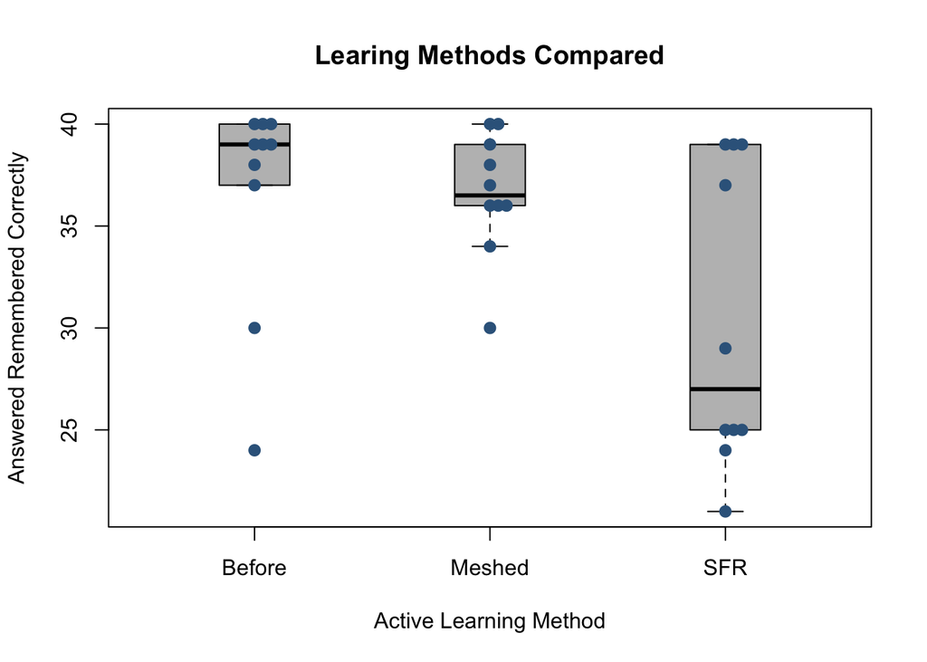

The actual summary values depicted in the plot above are shown in the following table.

```r
Friendly %>%
  group_by(condition) %>%
  summarise(min = min(correct), median = median(correct), mean = mean(correct), max = max(correct), sd = sd(correct), `Number of Students` = n()) %>%
pander(caption="Summary Of Results")
```

Summary Of Results

| condition | min | median | mean | max | sd | Number of Students |
| --- | --- | --- | --- | --- | --- | --- |
| Before | 24 | 39 | 36.6 | 40 | 5.337 | 10 |
| Meshed | 30 | 36.5 | 36.6 | 40 | 3.026 | 10 |
| SFR | 21 | 27 | 30.3 | 39 | 7.334 | 10 |

This Gives Us Some Numbers to explain what’s happening in the Data. The “vitals” of each approach if you would. Things like the exact median value which allows us to percisly see the difference in the data, and the range of the test results.

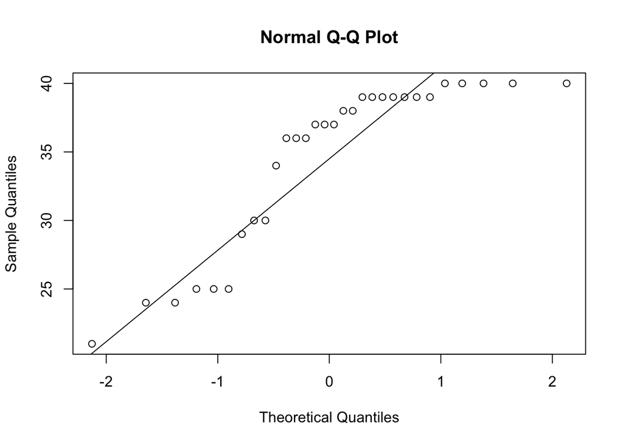

```r
qqnorm(Friendly$correct)
qqline(Friendly$correct)
```

As can be seen in the qqPlot the data is not normally distrbuted as it doesnt follow the patern the data points would suggest exisit from its distribution. Further in the graphs, The Data is not normally distrubted around be mean with clusters on either side and outliers skewing it, further, we can see that the sample size (or total number of people in each sample) is less than 30 meaning it doesnt satisfy the requirements of a T test. However we can use a wilcox test.

## Hypothosis

Because a the data is too adnormally distrbuted for a T test we have to use a Wilcox test. Which uses the Median of a sample rather and a mean, meaning it can be satisifed with much smaller populations and still come closer to finding the true median than an average from such a small population would. It would be even better to have an itaritive approach.

Formally, the null and alternative hypotheses are written as
$$H_0: \text{difference in medians} = 0$$

$$H_a: \text{difference in medians} \neq 0$$

The significance level for this study will be set at
$$\alpha = 0.05$$
Meaning, an P value that comes back lower than .05 would indicate the difference in the data is signficant.

## The Active Methods Compared

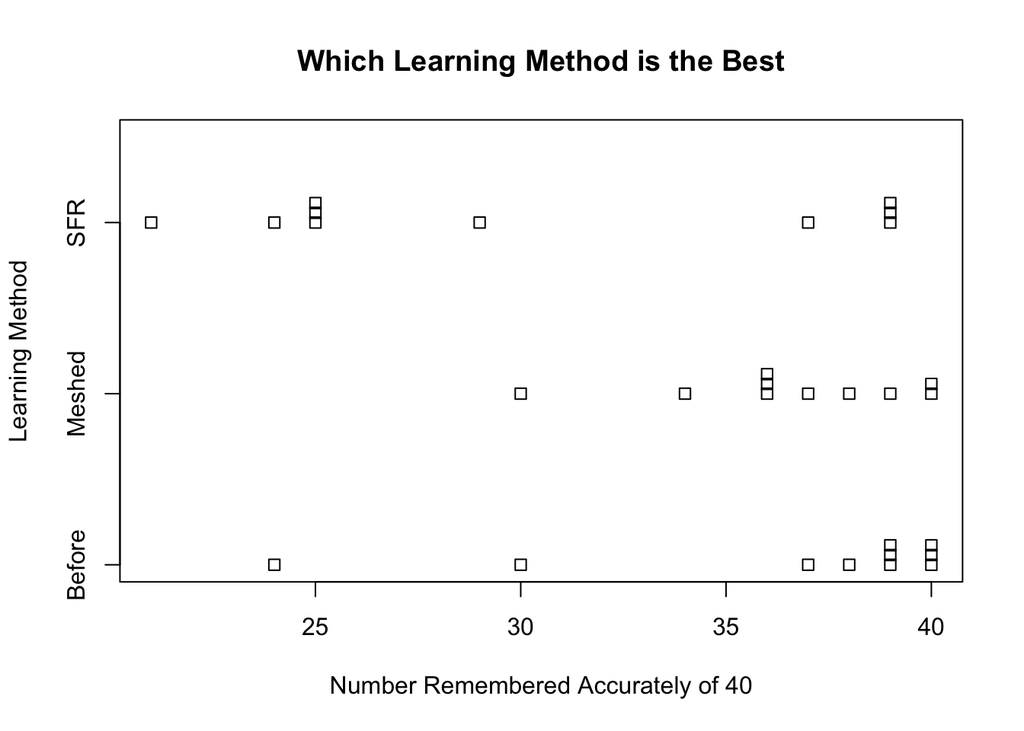

```r
stripchart(Friendly$correct~Friendly$condition, method="stack", xlab="Number Remembered Accurately of 40", main="Which Learning Method is the Best", ylab="Learning Method")
```

As seen above the control or SFR were no active learning method was used has by far the lowest preformance meaning, that both active methods acutally contribute to some degree of improved retention of information.

However the test I wish to preform is if there is a difference between the two “active” methods. Meaninga test between the Medians of the Before and the Meshed Approach.

Thankfully the control Group is the lowest of the three (meaning these other methods accutally are helping students improve their preformance) Which leaves the question, which of the Meshed and Before is the better method. Since a mean comparision is maybe unussable from the data sizes being too small in the first place. We are left with a Wilcox Test.

The test used here will have to be to determine if there is any difference between the two

## Wilcox Test

```r
pander(
wilcox.test( correct ~ condition, data=F5, mu=0, alternative="two.sided" , confidence=0.95)
)
```

[output not shown]

## Conclusion

Further. The benifit or repetition is to be noted. That said the “its all on you to remember all this approach” could lead to those higher number of perfect scores.

While many other factors exisit to be tested for example. Such as perhaps a techinques used by the individuals in the test or any number of other factors. A larger sample size would be recommened in the future to help by hope of the viture of larger sample size account for any specail single circumstance. Even then other matters exisit. But if it were to be used over time and conducted repeatedly parterns could begin to develop again, that said. This does not preclude that there is not more out there, perhaps a technique not tried yet, or a group of people that have developed characitsitcs or ablilities that would render this teaching method unnecesary. But such a instance would appear as a case when the SFR would be greater. Still, good to know educations helps us learn information better. That said, true education will always be in teaching a man to think and not what to think.